# Network Assignment

Dr. Samantha Ajovalasit

### 0) Clean all data from enivornment and load the igraph library

```r
rm(list = ls())
library(igraph)
```

## 1) Unzip the network.csv.zip file, then load the Dolphin Social Network*

*D. Lusseau et al., “The bottlenose dolphin community of Doubtful Sound features a large proportion of long-lasting associations.” Behavioral Ecology and Sociobiology 54(4), 396-405 (2003)., https://doi.org/10.1007/s00265-003-0651-y [@sci-hub]

### 1.1) load the file “edges.csv” as dataframe and then as graph, load also the nodes as undirected graph

```r
g1 <- read.csv('dolphin/edges.csv')
g1.nodes <- read.csv('dolphin/nodes.csv')


g1 <- graph_from_data_frame(g1, directed = F,vertices = g1.nodes)
class(g1)
```

```
## [1] "igraph"
```

### 2) Get all simple information from the graph, number of vertices and edges

```r
str(g1)
```

[output not shown]

```r
vcount(g1)
```

```
## [1] 62
```

```r
ecount(g1)
```

```
## [1] 159
```

```r
gsize(g1)
```

```
## [1] 159
```

### 3) Check if the graph is connected

connected means that any two vertices are reachable from each other with a multihop path i.e. not isolated vertices

```r
is.connected(g1)
```

```
## [1] TRUE
```

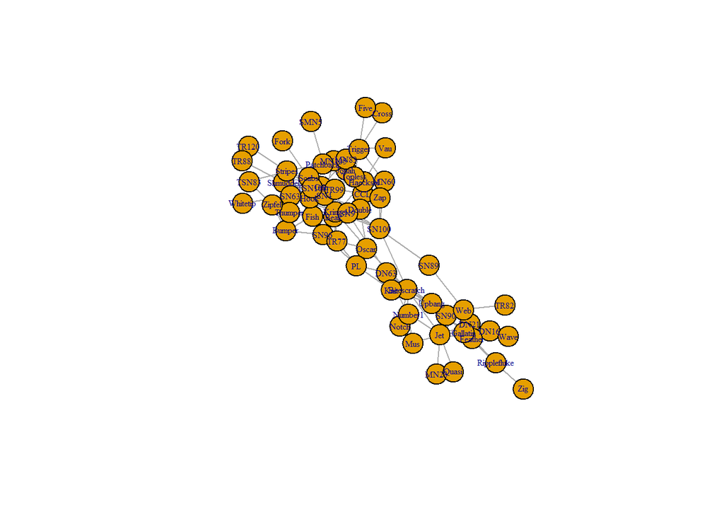

```r
plot(g1, vertex.label.cex=0.5)
```

```r
g1.conn <- delete_vertices(g1, which(degree(g1)==0))
g1.conn
```

```
## IGRAPH a441730 UN-- 62 159 --
## + attr: name (v/c), label (v/c), X_pos (v/c)
## + edges from a441730 (vertex names):
##  [1] 3 --8  5 --9  6 --9  0 --10 2 --10 5 --13 6 --13 9 --13 0 --14 3 --14
## [11] 0 --15 14--16 1 --17 6 --17 9 --17 13--17 15--18 1 --19 7 --19 8 --20
## [21] 16--20 18--20 18--21 17--22 14--24 15--24 18--24 17--25 1 --26 25--26
## [31] 1 --27 7 --27 17--27 25--27 26--27 1 --28 8 --28 20--28 10--29 18--29
## [41] 21--29 24--29 7 --30 19--30 28--30 17--31 9 --32 13--32 12--33 14--33
## [51] 16--33 21--33 14--34 33--34 29--35 1 --36 20--36 23--36 8 --37 14--37
## [61] 16--37 21--37 33--37 34--37 36--37 14--38 16--38 20--38 33--38 36--39
## [71] 0 --40 7 --40 14--40 15--40 33--40 36--40 37--40 1 --41 9 --41 13--41
## + ... omitted several edges
```

```r
is.connected(g1.conn)
```

```
## [1] TRUE
```

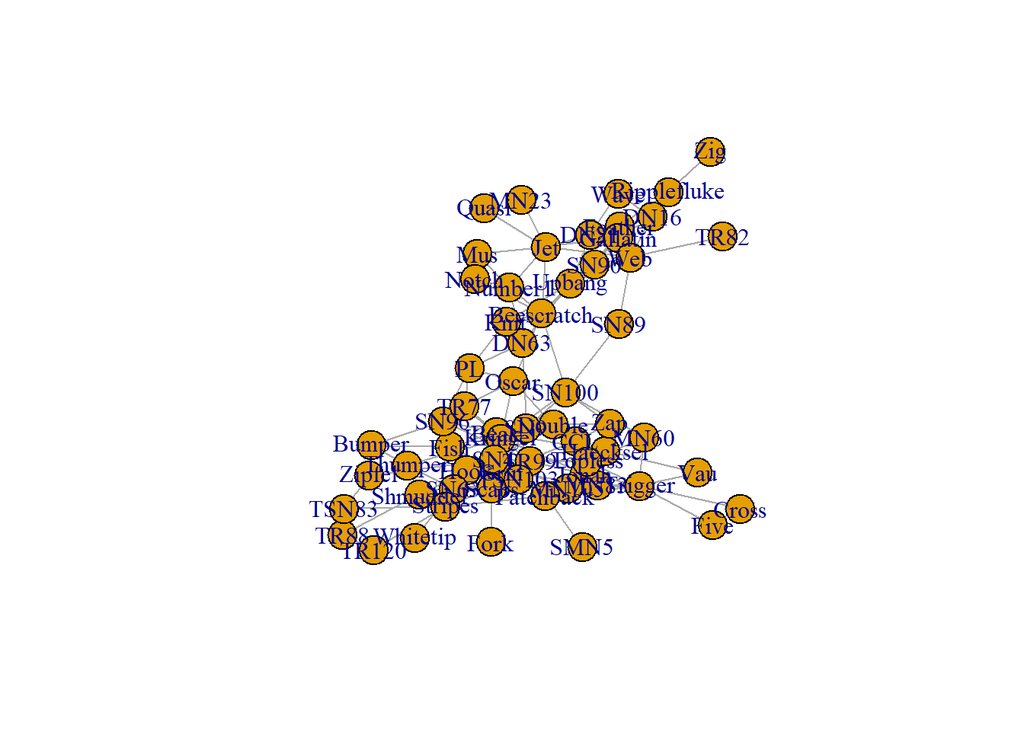

```r
plot(g1.conn)
```

### 4) Plot the graph

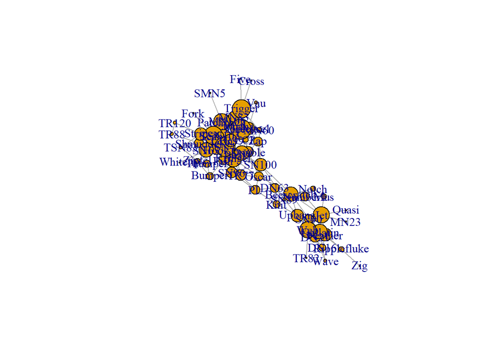

```r
plot(g1, vertex.size= degree(g1)*2)
```

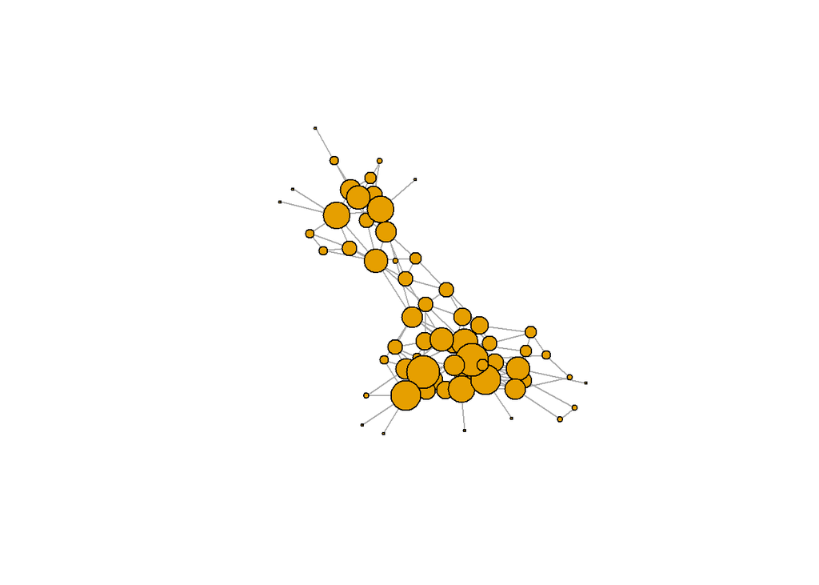

```r
plot(g1, vertex.size= degree(g1)*2, vertex.label=NA)
```

### 5) Plot with a different layout

```r
help('layout_')
```

```
## starting httpd help server ... done
```

```r
lay1 <- layout_(g1, as_tree())
lay2 <- layout_(g1, in_circle())
```

Plot with the two layouts

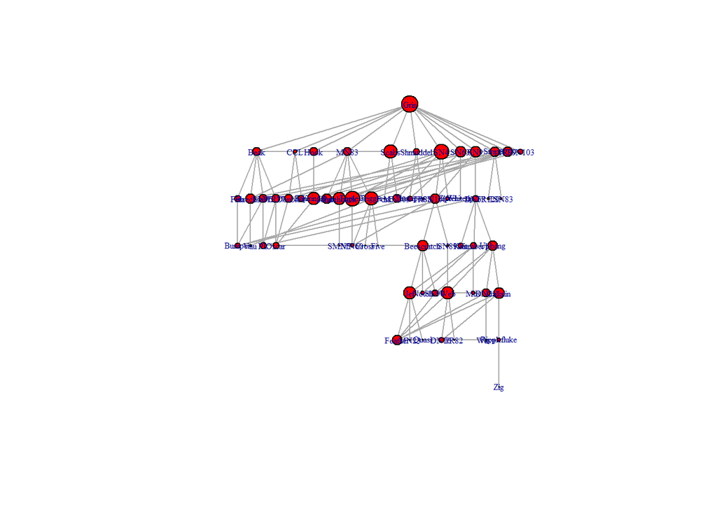

```r
plot(g1, vertex.size= degree(g1),
     vertex.color='red', layout=lay1, vertex.label.cex=0.5)
```

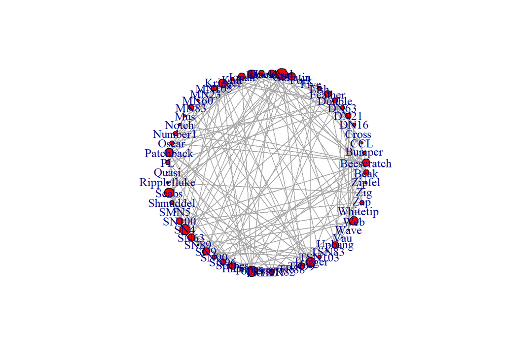

```r
plot(g1, vertex.size= degree(g1),
     vertex.color='red', layout=lay2)
```

### 6)Get the Diameter of a graph

The diameter of a graph is the length of the longest geodesic path.

```r
diameter(g1, directed = F)
```

```
## [1] 8
```

```r
diam <- get_diameter(g1, directed=F)
diam
```

```
## + 9/62 vertices, named, from a423f91:
## [1] 4  51 23 36 1  17 9  32 60
```

### 7) Get the degree of the graph and plot the graph based the value of the degree

##### Plot the histogram

DEGREE OF A NODE depends if we have a directed or undirected graph if we have a directed one the in degree and the out degree (edges out of vertex) are often different, while if undirected we have bidirectional edges and then they are equal.

High degree nodes attract a lot of connections. They are hubs, very important for the functioning of the network killing high degree nodes may be much more serious than killing low degree nodes

```r
deg <- degree(g1, mode='all')
deg
```

```
##  0  1  2  3  4  5  6  7  8  9 10 11 12 13 14 15 16 17 18 19 20 21 22 23 24 25
##  6  8  4  3  1  4  6  5  6  7  5  1  1  8 12  7  6  9  7  4  9  6  1  3  6  3
## 26 27 28 29 30 31 32 33 34 35 36 37 38 39 40 41 42 43 44 45 46 47 48 49 50 51
##  3  5  5  9  5  1  3 10  5  1  7 11  8  2  8  5  6  7  4 11  2  6  1  2  7 10
## 52 53 54 55 56 57 58 59 60 61
##  4  2  7  2  2  9  1  5  1  3
```

```r
max(deg)
```

```
## [1] 12
```

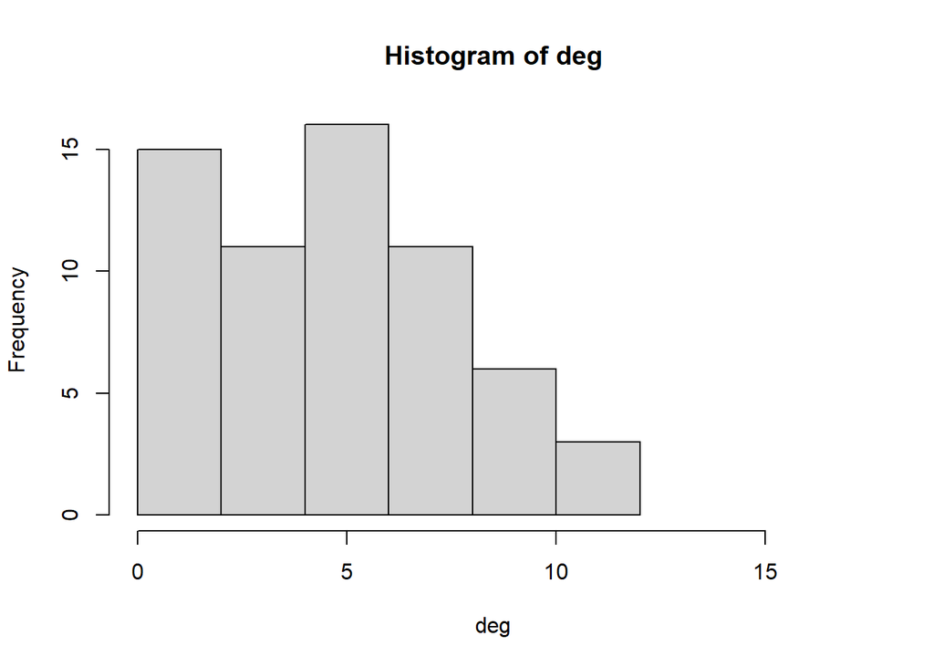

```r
hist(deg, xlim=c(0,max(deg)+5))
```

Plot based on degree distribution

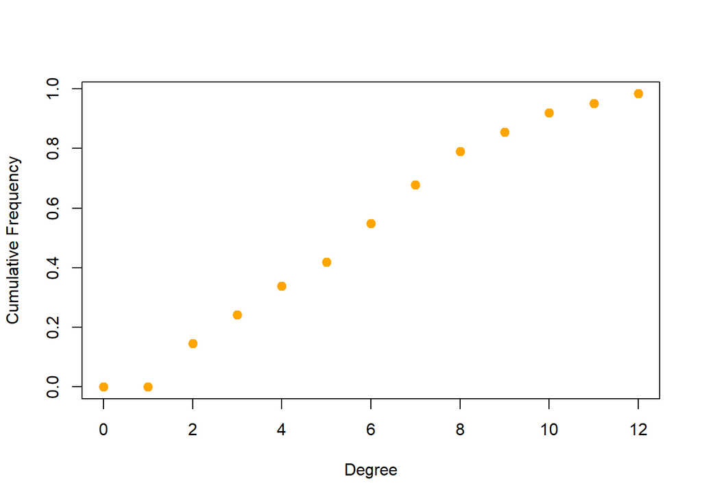

```r
deg.dist <- degree_distribution(g1, cumulative=T, mode="all")
plot( x=0:max(deg), y=1-deg.dist, pch=19, cex=1.2, col="orange", xlab="Degree", ylab="Cumulative Frequency")
```

##### What we can say about the degree distribution?

# 8) Calculate the average path length of the graph and all possible distances

```r
mean_distance(g1, directed=F)
```

```
## [1] 3.356954
```

```r
#distances(g1)
```

# Calculate some basic centrality measures of the graph

## 10) Calculate Eigenvector centrality measure and plot it in a proper way with proper color

#### set the maximum four digits

Eigenvector centrality measures is similar to the concept of the google page rank it assigns to a vertex the importance score proportional to the importance score of its neighbor

```r
options(digits=4)
eigencen = eigen_centrality(g1)$vector
sort(eigencen, decreasing = T)
```

```
##       14       37       45       33       50       29       51       16
## 1.000000 0.951800 0.902535 0.890165 0.689372 0.670597 0.667174 0.658662
##       40       21       18       38       24       43       20       15
## 0.658275 0.656627 0.641247 0.622636 0.611856 0.602754 0.584191 0.519901
##        8       34       36       52        0       59       23       42
## 0.453166 0.439632 0.420422 0.410296 0.406936 0.354100 0.276653 0.256347
##       47        3       44       10       28       55       61        7
## 0.254512 0.251232 0.246379 0.238308 0.216046 0.165018 0.164643 0.135856
##        1       30        2       12       53       46       35       11
## 0.133244 0.129036 0.125900 0.123744 0.106678 0.094104 0.093221 0.092745
##        4       58       49       54       39       19       17       57
## 0.092745 0.086554 0.074196 0.072841 0.066093 0.065472 0.055457 0.055026
##       27       41       13        9        6       26        5       25
## 0.051672 0.048272 0.047516 0.038626 0.038606 0.028323 0.020771 0.018830
##       32       56       31       22       48       60
## 0.012211 0.008254 0.007709 0.007709 0.007649 0.001697
```

Cut identifies the corresponding bin for each score

```r
bins <- unique(quantile(eigencen, seq(0,1,length.out=30)))
vals <- cut(eigencen, bins, labels=FALSE, include.lowest=TRUE)
length(vals); head(vals)
```

```
## [1] 62
```

```
## [1] 20 14 13 18 10  4
```

then we will assignt the color of each bin to a variable

```r
my_col = heat.colors(length(bins))
head(my_col)
```

```
## [1] "#FF0000" "#FF0C00" "#FF1700" "#FF2300" "#FF2E00" "#FF3A00"
```

```r
colorVals <- rev(my_col)[vals]
V(g1)$color <- colorVals
```

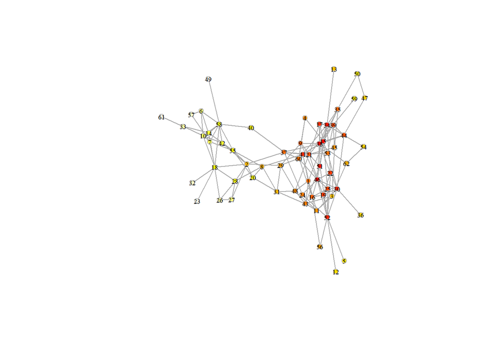

```r
set.seed(1)
plot.igraph(g1, vertex.size=5, vertex.label=V(g1),
            vertex.label.color="black",
            vertex.frame.color="gray",
            vertex.label.cex=0.6)

subgraph = subgraph_centrality(g1)
```

```r
subgraph = subgraph_centrality(g1)
#'The subgraph centrality of a vertex is defined as the number of closed loops originating at the vertex, where longer loops are exponentially downweighted.
```

# 10) Calculate Betweenness centrality measure, find its correlation with the eigenvector centrality

Plot it properly.

The `betwenness centrality` says how much paths between any other nodes go trough that node.

This idea is based #in part, on a seminal #paper by Mark Granovetter called `"The strength of weak ties"` in which it was shown that most job seekers (who participated in the study) found their ultimate employment through a weak tie, that is, through an acquaintance, rather than a strong tie or a close friend.

```r
betwenness = igraph::betweenness(g1)

sort(betwenness,decreasing=TRUE)[1:10]
```

```
##    36     1    40    37     7    17    20    54    51    57
## 454.3 390.4 262.0 253.6 216.4 209.2 187.8 181.4 155.0 154.1
```

```r
cor(betwenness,eigencen)
```

```
## [1] 0.2835
```

Plot based on betwenness

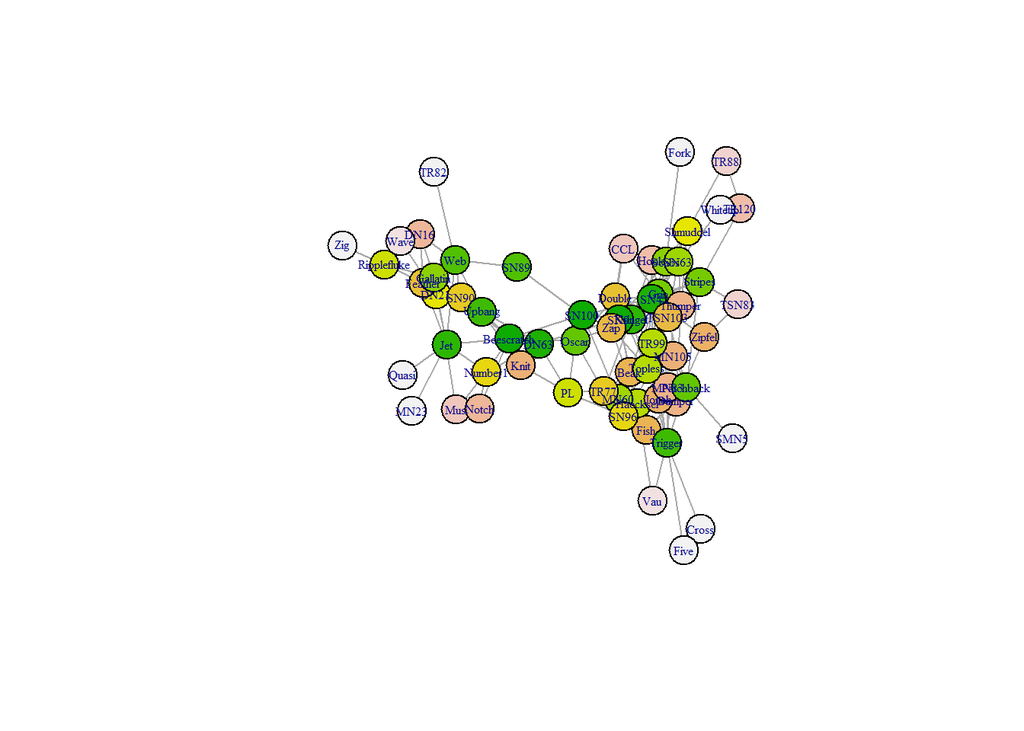

```r
bins <- unique(quantile(betwenness, seq(0,1,length.out=30)))
vals <- cut(betwenness, bins, labels=FALSE, include.lowest=TRUE)

colorVals <- rev(terrain.colors(length(bins)))[vals]
V(g1)$color <- colorVals
set.seed(1)
plot.igraph(g1, vertex.size=V(g1)$deg,
            vertex.label.cex=0.5)
```

# 11) Calculate the Edge Betweenness centrality measure it is basically a clustering measure and plot it

`Its a clustering measure`. The measure helps to find the `community`, and isolate them,

```r
w <- edge.betweenness.community(g1)
sort(table(w$membership))
```

```
##
##  5  1  4  3  2
##  2  7 12 20 21
```

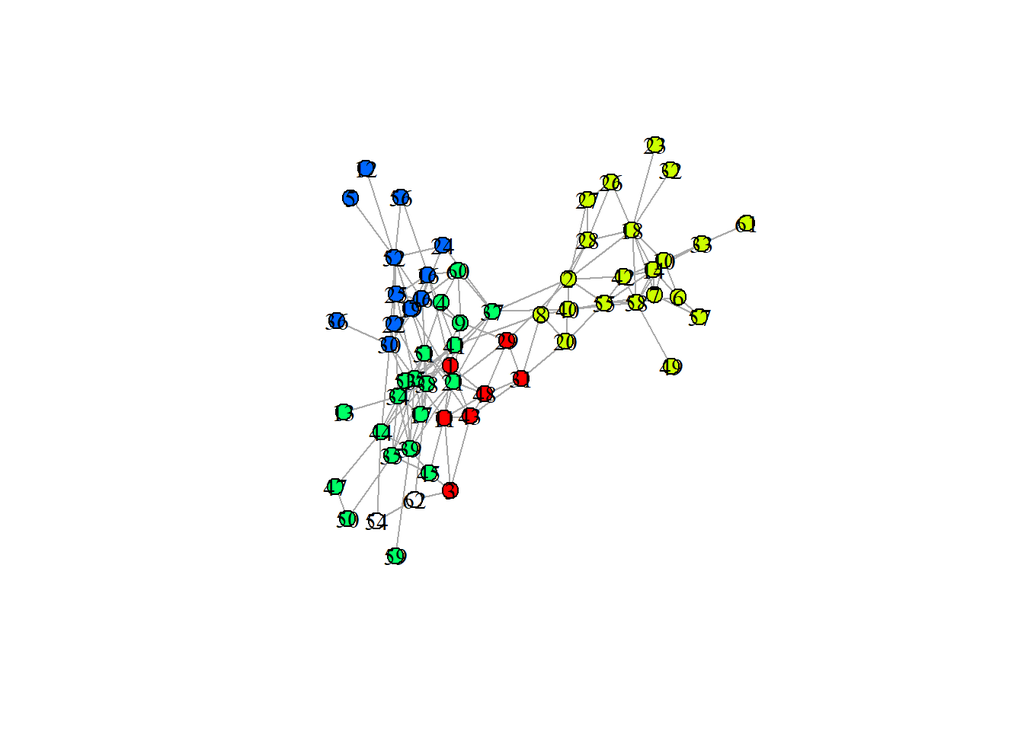

```r
V(g1)$color <- rep("white", length(w$membership))
keepTheseCommunities <- names(sizes(w))[sizes(w) > 3]
matchIndex <- match(w$membership, keepTheseCommunities) # like %in%
colorVals <- rainbow(5)[matchIndex[!is.na(matchIndex)]]
V(g1)$color[!is.na(matchIndex)] <- colorVals


plot.igraph(g1, vertex.size=8, vertex.label= V(g1), vertex.label.color='black', vertex.cex=0.6)
```